# Intro to github and version control

- COVID19 computational workshop *4/16/20 @mfpfox*

Backus lab github link : https://github.com/BackusLab

```python
### PACKAGES #################
import os
import sys
import argparse
import pandas as pd
import csv
import numpy as np
from IPython.display import Image
from IPython.core.display import HTML

### SET WORKING DIRECTORY #################
PATH = "/Users/mariapalafox/Desktop/Cheatsheets/Lab_meeting_tutorials/Rstudio_git_images/"
os.chdir("/Users/mariapalafox/Desktop/Cheatsheets/Lab_meeting_tutorials/Rstudio_git_images/")
print(os.listdir())
# sys.path.append("/Users/mariapalafox/Desktop/Toolbox")

### FUNX FOR ADDING IMAGES TO JUPYTER NOTEBOOKS
def smallpic(name):
    # type 'smallpic('image1.png')'
    display(Image(filename = PATH + name, width= 500, height=600))

def largepic(name):
    display(Image(filename = PATH + name, width= 700, height=600))
```

```
['merge_screenshot.png', 'Rgit_url.png', 'github_cloud2.png', 'github_cloud3.png', 'github_cloud1.png', 'github_cloud4.png', 'github_cloud5.png']
```

# case 1: Heta stores her favorite recipes on github. Jose and Jian would like to start from Heta's recipes, and collaborate on new versions based on their taste preferences.

- git clone remote repository to your computer
- good for starting seperate collaborations based on existing github repos
- issue: no history of who made recipe repo

```
## reset your local repo remote origin to the url copied
git remote set-url origin https://github.com/___/___.git
git status
git push
## confirm files added to your github account

#### alternatively:
- if you wanted to connect a folder on your computer to your github account, use this command to set remote:
git remote add origin https://github.com/___/___.git
git remote -v # sets origin
```

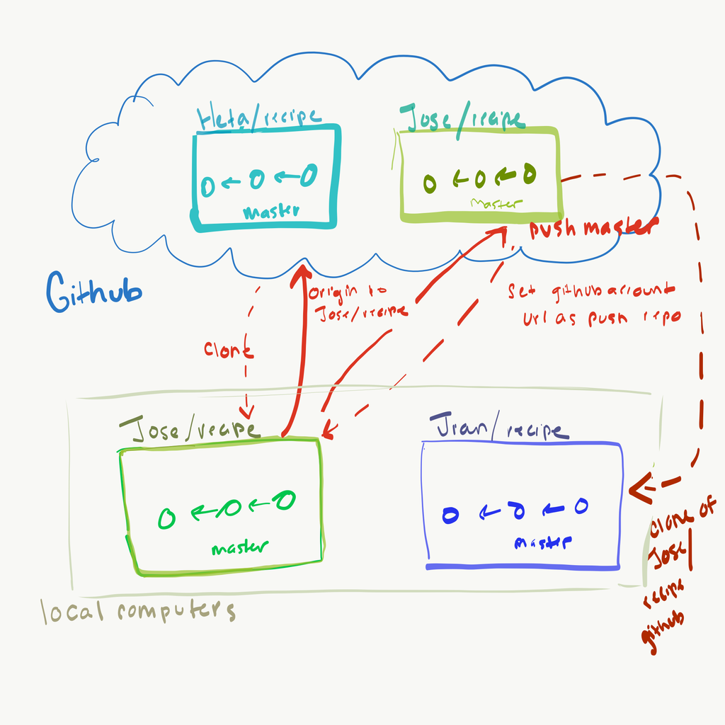

```python
largepic('github_cloud1.png')
```

# case 2: similar to case 1, but now using the github 'fork' method to copy the original recipes repo to her github account

- git fork *__* (skips cloning to local computer step)
- good for maintaining collaboration with original author with suggestions
- issue: github tracks who forks original repo, and to make significant changes to content of repo, you will need to first clone data to your computer.

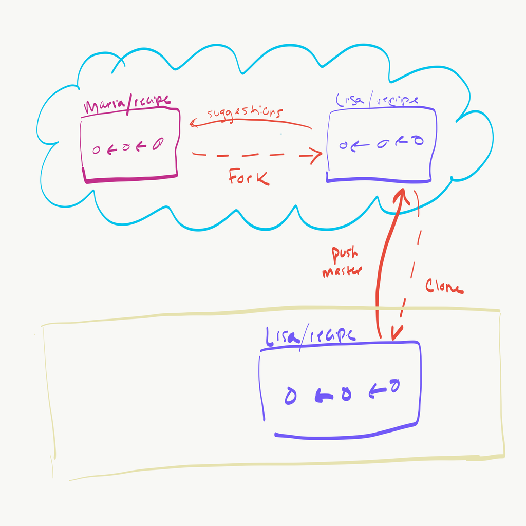

```python
largepic('github_cloud2.png')
```

# case 3: similar to case 2, but with lab members forking repo COVID/ from BackusLab github to member github accounts

- same strenths and issues as case 2

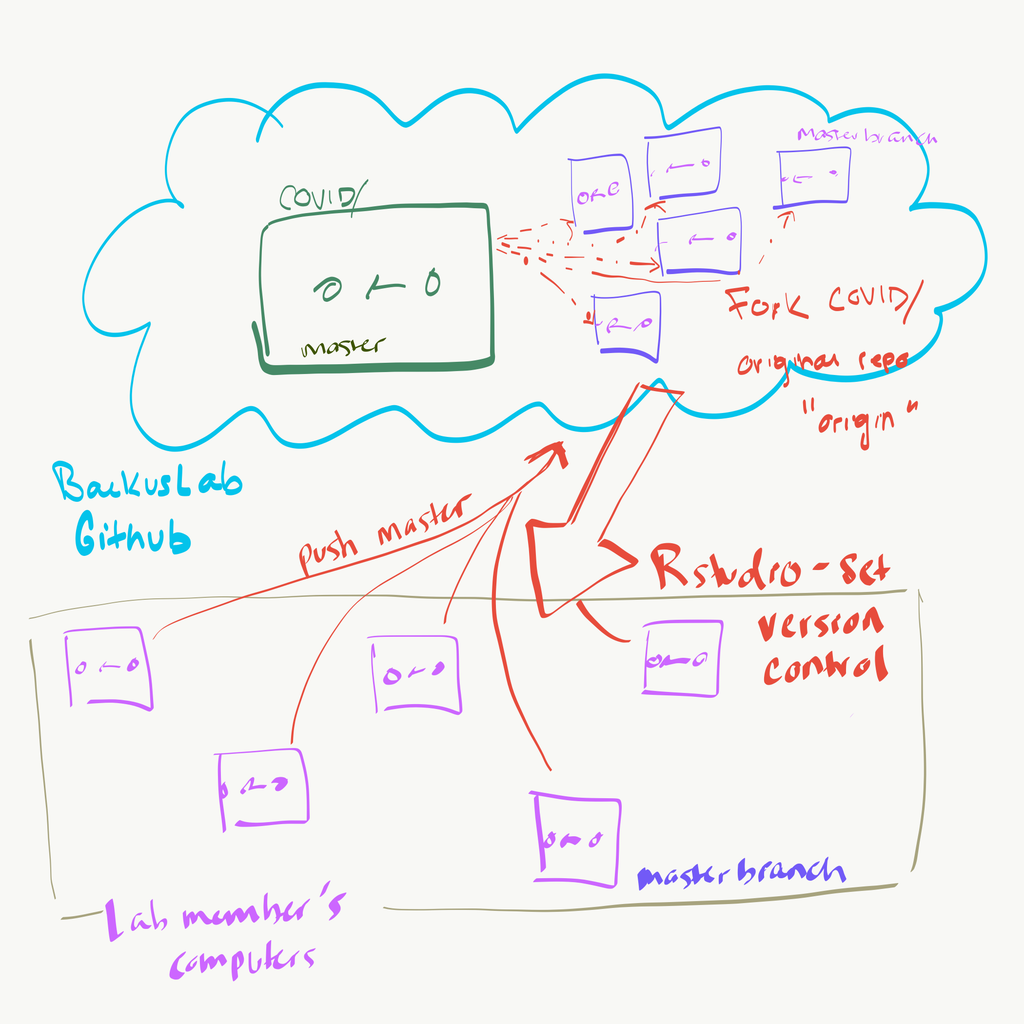

```python
largepic('github_cloud3.png')
```

# 3 main git commands:

> git add *__*

> git commit -m "..."

> git push

## [1] git clone repository on BackusLab account

```
# to download cheatsheet to local computer
git clone ____ (url of remote)
```

## [2] on your computer, login to github and 'Fork' BackusLab/testme to your personal account

```
## on your account, copy url of forked repo
# on computer in terminal or in desktop app:
git clone https://github.com/youraccount/testme.git
cd testme
git status # clean branch
touch change.txt # create new file
git status # untracked file
git add . # add all files
git status # shows changes staged for commit step
git commit -m "" # add message
git push
## confirm files added to your github account
```

## [3] merge conflict example

- make edits to file locally
- commit changes
- on github: create new file in repo
- on computer: push staged changes to remote
- dont panic

**WARNING: google all error messages before force overriding a merge conflict**

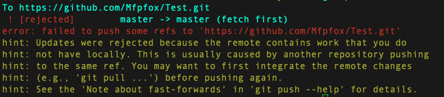

```python
largepic("merge_screenshot.png")
```

### resolve merge conflict:

```
git pull # integrate remote changes
## type 'i' to insert message in git prompt
## then type 'ESC' ':wq' saves message or ':q' to escape no save

# now you should be able to stage local change and push to remote
git add .
git commit -m "that wasn't so bad after all"
git push
```

## [3] create new Rstudio project from forked repo

- fork BackusLab/Rstudio_github repo to your account
- in your forked repo, copy url (https instead of ssh option)
- in Rstudio, create new project, select option to create from github
- enter copied url of remote repo

### under git tab in Rstudio

- add the name or file '.Rproj' to the .gitignore file
- save changes to file
- git commit '.gitignore' by checking box 'staged' and clicking 'commit'
- add commit message, click commit
- push to your remote account, check if changes reflected on account

[figure not shown]

```python
largepic("Rgit_url.png")
```

# Summary of git commands :

### 1. Introduction to Version Control Systems

$ git init

### 2. The .git Folder

$ ls -al

### 4. Checking File Status

$ git add README.md

### 5. Configuring Identity in Git

$ git config --global user.name "MFP"

### 6. Committing Changes

$ git commit -m "Initial commit. Added script.py

$ git status

### 8. Making a Second Commit

$ git commit -m "added random function "

### 9. Viewing Commit Differences

$ git log --stat